# Can external factors reduce fire losses in Toronto?

Jie Huang(1004925156)

2020/12/22

Code and data supporting this analysis is available at:https://github.com/JaneHHH/STA304-Final-Project

## Keywords

Propensity Score, Observational Study, Fire incidence, Causal Inference, Prevention Method

## Introduction

The Canadian government widely uses statistical analysis in daily life. The most common ones are the crime rate and divorce rate. At the same time, statistical analysis can also summarize the recent fire incidences in Toronto and the casualties and property losses in the incidence. It is scientifically that “fire presents a significant risk to businesses. It can kill or seriously injure employees or visitors and can also damage or destroy buildings, equipment or stock.”[1] In other words, with these data, the government can analyze these cases, then improve fire protection measures, or cause attention to reducing the fire incidences as possible.

In the step-by-step analysis, the first step, I sort the dataset and clean the data to keep the main variables that I need, removing the NAs to reduce errors. Then I summary each variable and build a multiple linear regression model based on sorted data. Finally, I make a discussion on the results, strengths, and weaknesses of the model.

# Data

I download the datasets from the Toronto Open Data Potral. Then I use R studio to run code to help us select the valid respondents and clean the data with missing values(NA) and the undetermined data(99 - Undetermined) in the variable Extent_Of_Fire. In this project, the target population is all fire cases in Toronto in 2020; the frame is 17536 cases; the sample is 1000 cases. The 1000 cases are randomly selected from the dataset.

Table1: Extent of Fire

| Number | Description of fire extent |
| --- | --- |
| 1 | Confined to object of origin |
| 2 | Confined to part of room/area of origin |
| 3 | Spread to entire room of origin |
| 4 | Spread beyond room of origin, same floor |
| 5 | Multi unit bldg: spread beyond suite of origin but not to separated suite(s) |
| 6 | Multi unit bldg: spread to separate suite(s) |
| 7 | Spread to other floors, confined to building |
| 8 | Entire Structure |
| 9 | Confined to roof/exterior structure |
| 10 | Spread beyond building of origin |
| 11 | Spread beyond building of origin, resulted in exposure fire(s) |

Table1 shows that the extent of fire control and the ordering number will determine the different extent.

| Number | Description of fire control |
| --- | --- |
| 1 | Extinguished by fire department |
| 2 | Extinguished by automatic system |
| 3 | Extinguished by occupant |
| 4 | Fire self extinguished |
| 5 | Action taken unclassified |

Table2 shows that the method of fire control and the ordering number will determine the different styles. Still, I try to change these two tables’ descriptions as numerical variables, summarized as a table to see the sum of various types and the relationship by plots.

Below is the overall summary table for our dataset: Table3: Summary Table for the Overall Dataset

```
##  Extent_Of_Fire     Method_Of_Fire_Control Civilian_Casualties
##  Length:1000        Length:1000            Min.   :0.000
##  Class :character   Class :character       1st Qu.:0.000
##  Mode  :character   Mode  :character       Median :0.000
##                                            Mean   :0.104
##                                            3rd Qu.:0.000
##                                            Max.   :4.000
##  Count_of_Persons_Rescued Estimated_Dollar_Loss Number_of_responding_personnel
##  Min.   :0.000            Min.   :       0      Min.   :  4.00
##  1st Qu.:0.000            1st Qu.:     200      1st Qu.: 20.00
##  Median :0.000            Median :    2000      Median : 22.00
##  Mean   :0.051            Mean   :   36671      Mean   : 28.76
##  3rd Qu.:0.000            3rd Qu.:   10000      3rd Qu.: 34.00
##  Max.   :7.000            Max.   :13000000      Max.   :246.00
##   extent_fire      fire_control
##  Min.   : 1.000   Min.   :1.000
##  1st Qu.: 1.000   1st Qu.:1.000
##  Median : 2.000   Median :1.000
##  Mean   : 2.024   Mean   :1.837
##  3rd Qu.: 2.000   3rd Qu.:3.000
##  Max.   :11.000   Max.   :5.000
```

In the table3, I can find that the mean of the civilian casualties is 0.104, which means that the value of civilian casualties in the fire incidence is not large. Most of people are safe in the fire incidence, meaning that the fire awareness is very strong. The IQR in the count of persons rescued is 0. And the maximum value of the estimated dollar loss is 13000000. When the fire incidence happened, there are minimum 4 responding people around and try to help the firemen to extinguish the fire and save people.

# Model

I use R studio to build three simple linear regression models to see the association between the three independent variables and the response variable. In addition, it is appropriate to use a simple regression model to analyze the dataset, predicting the relationship between the dependent and independent variable. ‘Linear regression is the most basic and commonly used predictive analysis. Regression estimates are used to describe data and to explain the relationship between one dependent variable and one or more independent variables. At the center of the regression analysis is the task of fitting a single line through a scatter plot.’[2] Besides, I set up a null hypothesis that the coefficients of predictor variables are equal to zero, indicating no association between the dependent and the independet variable. Meanwhile, I choose the significance level of 0.05, to compare it with the p-value.

Plot1: Scatterplot of personnel and civilian casualties

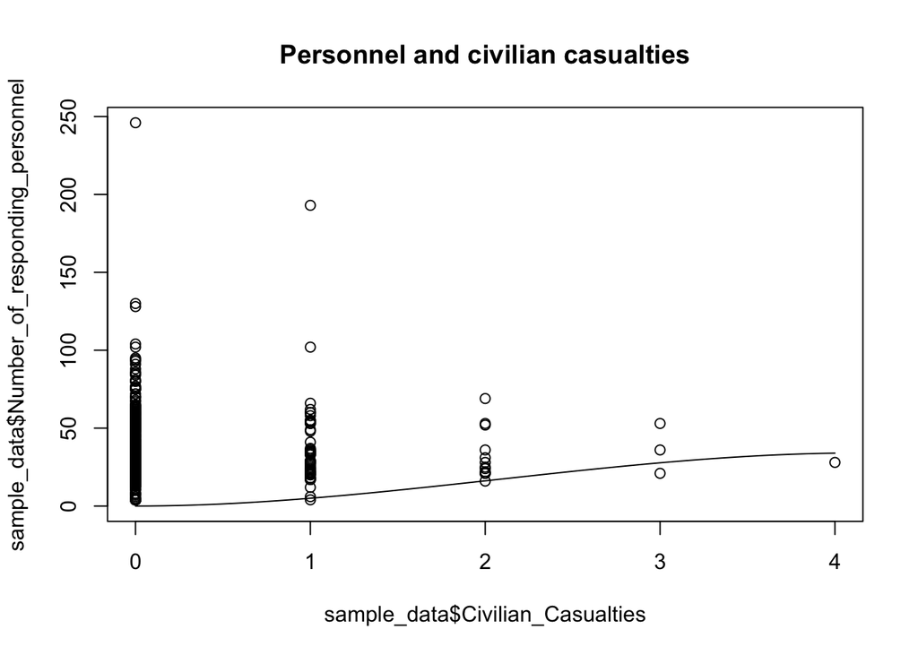

The Plot1 along with the smoothing line above suggests a weak linearly increasing relationship between the number of responding personnel and civilian casualties variables. This is a good thing, because, one of the assumptions in linear regression is that the relationship between the response and predictor variables is linear. And there are some outliers in the plot.

Plot2: Scatterplot of personnel and persons rescued

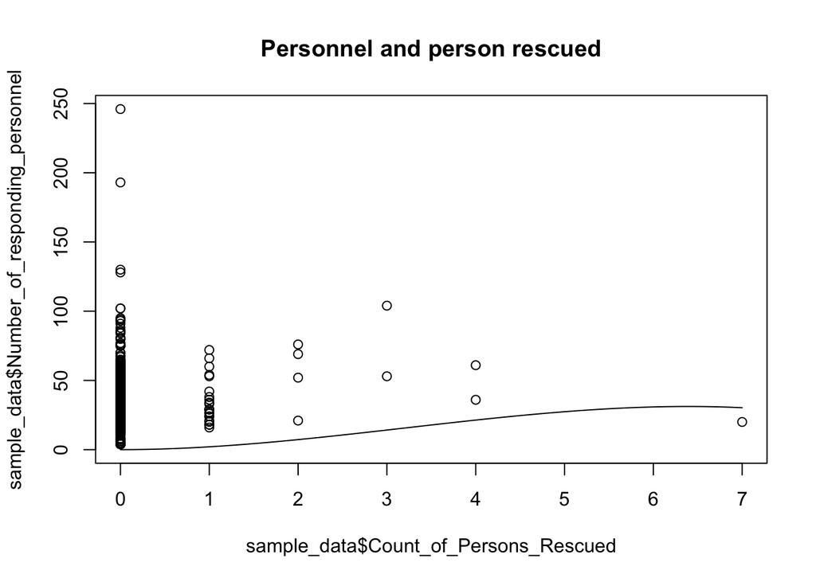

There is a weak positive increasing line in the plot2 with some outliers.

Plot3: Scatterplot of personnel and estimated dollar loss

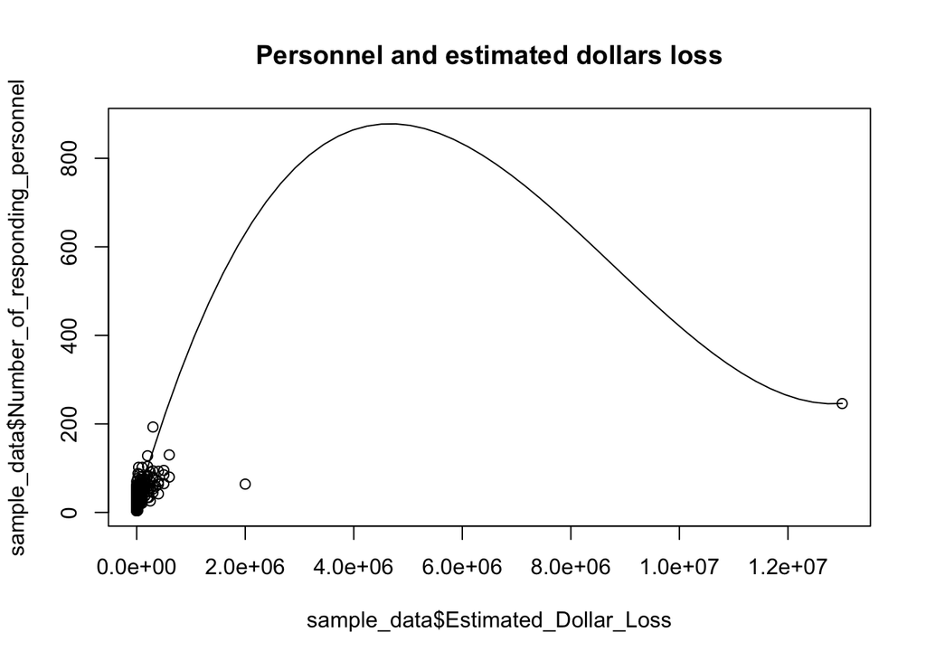

The line in this plot is incresing at the beginning, then it starts to decrease. There are some outliers in this plot.

## Results

Table3: Summary Table for Regression Model

```
##
## Call:
## lm(formula = Number_of_responding_personnel ~ Civilian_Casualties,
##     data = sample_data)
##
## Residuals:
##     Min      1Q  Median      3Q     Max
## -27.991  -8.386  -6.386   4.614 217.614
##
## Coefficients:
##                     Estimate Std. Error t value Pr(>|t|)
## (Intercept)           28.386      0.600  47.311   <2e-16 ***
## Civilian_Casualties    3.605      1.500   2.404   0.0164 *
## ---
## Signif. codes:  0 '***' 0.001 '**' 0.01 '*' 0.05 '.' 0.1 ' ' 1
##
## Residual standard error: 18.32 on 998 degrees of freedom
## Multiple R-squared:  0.005756,   Adjusted R-squared:  0.004759
## F-statistic: 5.777 on 1 and 998 DF,  p-value: 0.01642
```

For the number of responding personnel and civilian casualties model, the simple linear function is
$$y = 28.386+3.605x_{civilian casualties}$$
. Table 3 shows the important value what I need.

Table4:Summary Table for Regression Model

```
##
## Call:
## lm(formula = Number_of_responding_personnel ~ Count_of_Persons_Rescued,
##     data = sample_data)
##
## Residuals:
##     Min      1Q  Median      3Q     Max
## -46.877  -8.481  -6.481   4.519 217.519
##
## Coefficients:
##                          Estimate Std. Error t value Pr(>|t|)
## (Intercept)               28.4813     0.5831  48.846  < 2e-16 ***
## Count_of_Persons_Rescued   5.4851     1.5753   3.482  0.00052 ***
## ---
## Signif. codes:  0 '***' 0.001 '**' 0.01 '*' 0.05 '.' 0.1 ' ' 1
##
## Residual standard error: 18.26 on 998 degrees of freedom
## Multiple R-squared:  0.012,  Adjusted R-squared:  0.01101
## F-statistic: 12.12 on 1 and 998 DF,  p-value: 0.0005195
```

Table5:Summary Table for Regression Model

```
##
## Call:
## lm(formula = Number_of_responding_personnel ~ Estimated_Dollar_Loss,
##     data = sample_data)
##
## Residuals:
##     Min      1Q  Median      3Q     Max
## -43.197  -8.044  -6.064   4.976 158.949
##
## Coefficients:
##                        Estimate Std. Error t value Pr(>|t|)
## (Intercept)           2.802e+01  5.181e-01   54.09   <2e-16 ***
## Estimated_Dollar_Loss 2.009e-05  1.230e-06   16.33   <2e-16 ***
## ---
## Signif. codes:  0 '***' 0.001 '**' 0.01 '*' 0.05 '.' 0.1 ' ' 1
##
## Residual standard error: 16.32 on 998 degrees of freedom
## Multiple R-squared:  0.2108, Adjusted R-squared:   0.21
## F-statistic: 266.6 on 1 and 998 DF,  p-value: < 2.2e-16
```

For the number of responding personnel and estimated dollar loss model, the simple linear function is
$$y = (2.802e+01)+2.009e-05x_{cestimated dollar loss}$$
. Table 5 shows the important values what I need.

–Diagonostic check: Plot4: 4 differnt plots

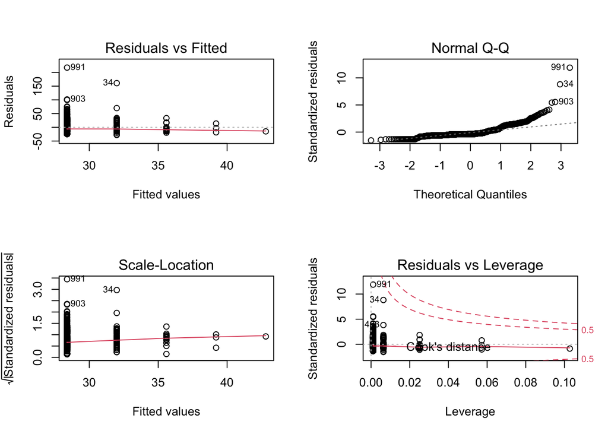

Plot5: 4 different plots

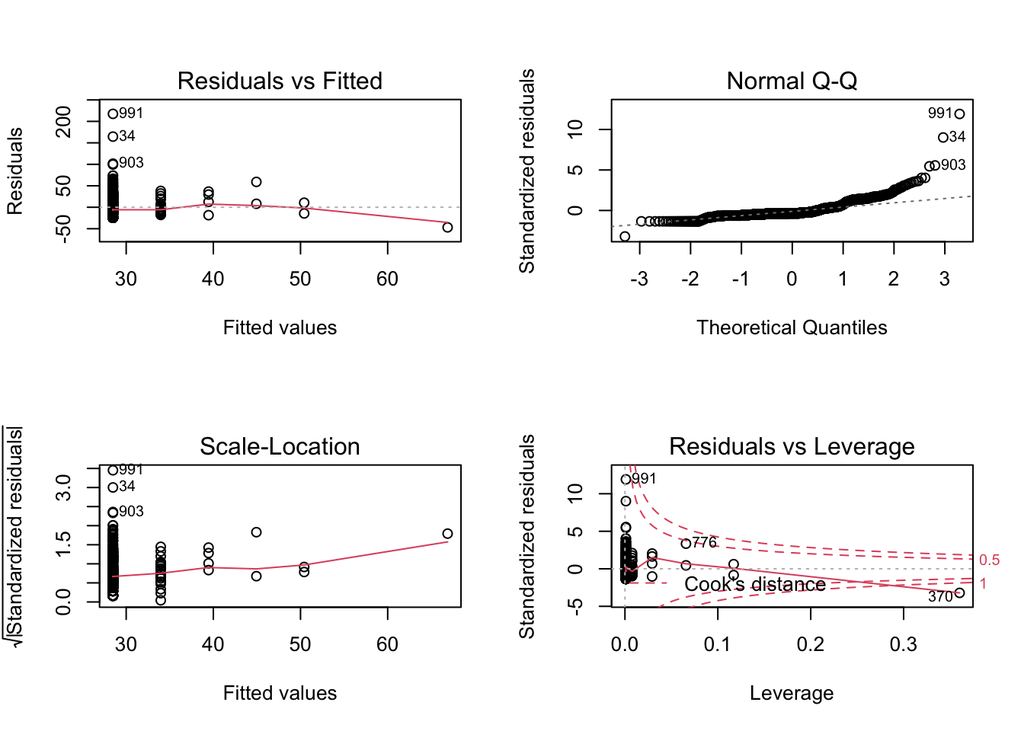

Plot6: 4 differnt plots

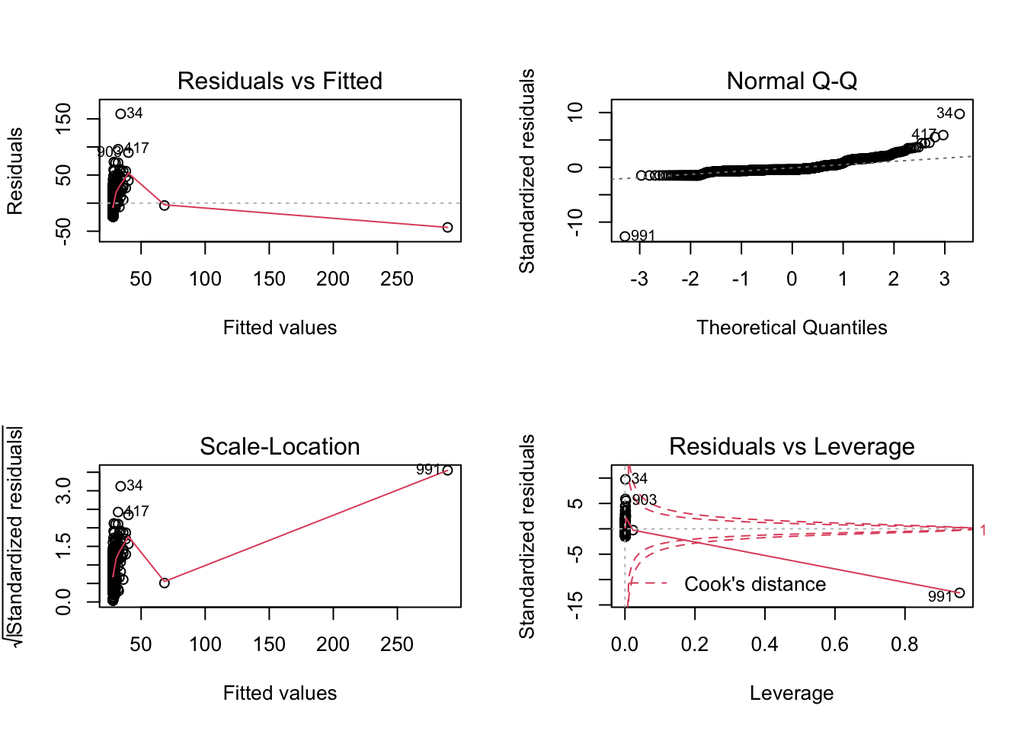